# Global Material Change : Sales Model

#### This demo is to show how to build a machine learning model in Python (sklearn) from beginning to end.

#### This is a binary classification model, to predict if a company will have more than 15% growth of sales in next 12 months.

#### The modelled population includes 24 countries. The dataset has been simplified for demo purpose.

- Data: Estimated Annual Sales
- Timeframe: observation as of Jan. 2014 (development sample)
- Model Type: Classification
- Algorithm: Random Forest (optimized hyperparameter)
- Filter : Estimated sales figure only
- Target Variable: Growth (vs. deterioration)

##### Author: Cris Liu

##### Date: 2016/4/26

### Import libraries

```python
import pandas as pd
import numpy as np
import matplotlib.pyplot as plt
from sklearn.metrics import roc_curve, auc
from sklearn.cross_validation import train_test_split
from sklearn.cross_validation import StratifiedKFold
from sklearn.metrics import confusion_matrix
from sklearn.metrics import roc_auc_score
from sklearn.metrics import f1_score
from sklearn.metrics import precision_recall_curve
from scipy import interp
import pandas.core.algorithms as algos
from sklearn.preprocessing import label_binarize
from sklearn.preprocessing import LabelEncoder
from sklearn.ensemble import RandomForestClassifier
import time
```

### Read the flat file into pandas dataframe

Header can be added into dataframe later, if it is not in the flat file.

```python
sample = pd.read_csv("/data2/GMC/sales_model/SALES_DEVELOPMENT_change.csv",header = None)
hd = pd.read_csv("/data2/GMC/sales_model/sales_header.csv",header = None)
sample.columns = hd.values.T[:,0]
sample.set_index(sample.duns,inplace=True)
```

### Filtering with sample with estimated sales

```python
sample.shape
```

```
(2300406, 523)
```

```python
sample.estimate_flag.value_counts()
```

```
0    1599946
1     700460
Name: estimate_flag, dtype: int64
```

#### '.copy()' ensures a new dataset will be created.

```python
df1_estimated_sales = sample[sample['estimate_flag']==1].copy()
df1_estimated_sales.shape
```

```
(700460, 523)
```

### Preprocess the data

This process includes several common data cleaning techniques.

```python
def preprocess(df):

    # Record values
    mktb_mapping = {
               np.nan: 0,
               'M': 1}

    dlst_mapping = {'N': 0,
               'Y': 1}

    df['dlst_ind_c'] = df['dlst_ind_c'].map(dlst_mapping)
    df['dlst_ind_p'] = df['dlst_ind_p'].map(dlst_mapping)

    df['mktb_ind_p'] = df['mktb_ind_p'].map(mktb_mapping)
    pd.unique(df.mktb_ind_p)

    #Create dummy variables
    df['SIC2D_P2'] = df['SIC2D_P'].astype(str)
    B = pd.get_dummies(df[['imp_exp_agt_code_ind_p','SIC2D_P2']])
    df = pd.concat([df,B],axis = 1)

    #Fill missing values
    df['glbl_hier_code_p'].fillna(99,inplace=True)
    pd.unique(df['glbl_hier_code_p'])

    #Drop unused variables
    df = df.drop([
                  'imp_exp_agt_code_ind_p','sales_grp_p','sales_grp_c','mfd_ind_p','SIC2D_P','SIC2D_P2'\
                  ],1)
    #Double check if there is any non-numeric variables
    for i,j in zip(df.columns,df.dtypes):
        if j!='int64' and j!='float64':
            print i ,j

    #Double check if there is any missing values
    def check_type(in1):
        A= in1.isnull().sum()
        if len(A[A>0].values)>0:
            print A[A>0]

    check_type(df)
    return df

df1_estimated_sales = preprocess(df1_estimated_sales)
```

### Check counts of DUNS with sales growth

```python
print df1_estimated_sales.increase_sales.value_counts()
print df1_estimated_sales.decrease_sales.value_counts()
print df1_estimated_sales.nochange_sales.value_counts()
```

```
0    516464
1    183996
Name: increase_sales, dtype: int64
1    516464
0    183996
Name: decrease_sales, dtype: int64
0    700460
Name: nochange_sales, dtype: int64
```

### Specify Target variables(y) and independent variables(X)

### Split the file into train and test datasets.

```python
def split1(df):
    y=df[['increase_sales','decrease_sales']]
    X=df.drop(['increase_sales','nochange_sales','decrease_sales','sales_pct_ALL','ann_sls_ind_c','ann_sls_ind_p',\
'ann_sls_us_dolr_amt_c','duns','hq_par_ctry_cd_c','dlst_ind_p','dlst_ind_c'],1)

    X_train, X_test, y_train, y_test = train_test_split(
             X, y, test_size=0.3, random_state=25)
    return X_train, X_test, y_train, y_test

X_train, X_test, y_train, y_test = split1(df1_estimated_sales)
```

### Use Random Forest to train and predict

- How to choose hyperparameters? Use Grid search to do cross-validation. Will be shown later.
- It takes less than 10 mins to train a dataset with 500K rows and 500 columns ,which produces 1000 trees !

```python
def train(X_train, X_test, y_train, y_test):

    #Define the algorithm, specify the hyperparameters
    forest = RandomForestClassifier(criterion='gini',
                                    n_estimators=1000,
                                    max_depth = 25,
                                    min_samples_leaf=25,
                                    max_features=50,
                                    n_jobs=-1
                                    )
    # Train the model with training dataset
    forest.fit(X_train, y_train,sample_weight = X_train.weight_sales.values)

    return forest

start_time = time.time()
forest = train(X_train, X_test, y_train['increase_sales'], y_test['increase_sales'])
print("--- %s seconds ---" % (time.time() - start_time))
```

```
--- 341.461439848 seconds ---
```

### Score the test dataset

- Output variable can be either Binary or Continuous(between 0 and 1)
- We choose to use continuous numbers and define our own thresholds later

```python
start_time = time.time()

#Binary output
y_pred = forest.predict(X_test)
#continuous output
proba = forest.predict_proba(X_test)


print("--- %s seconds ---" % (time.time() - start_time))
```

```
--- 8.74658608437 seconds ---
```

### Generate the Decile matrix (try different # of bins)

Also output KS values and monotonicity

```python
def assessment2(proba,y_test,num_bins):

        D = pd.DataFrame(proba[:, 1],columns = ['y_prob'])
        E = pd.DataFrame(y_test.values,columns=['y_test'])
        Results = pd.concat([D,E],1)
        del D,E
        bins = np.unique(algos.quantile(Results['y_prob'], np.linspace(0, 1, num_bins)))
        Results['decile']  = pd.tools.tile._bins_to_cuts(Results['y_prob'], bins,labels=np.arange( 0,len(bins)-1,1)[::-1], include_lowest=True)

        group = Results.groupby(['decile','y_test'])
        Results2 = group.y_test.count().unstack().fillna(0).sort_index(ascending=False)
        Results2.columns = ['Negative','Positive']
        Total_neg,Total_pos = Results2.sum()[0],Results2.sum()[1]
        Results2['Neg_perc'] = Results2['Negative']/Total_neg
        Results2['Pos_perc'] = Results2['Positive']/Total_pos
        Results2['Total_perc'] = (Results2['Negative']+Results2['Positive'])/(Total_neg+Total_pos)
        Results2['Cul_neg_perc'] = Results2['Neg_perc'].cumsum(axis=0)
        Results2['Cul_pos_perc'] = Results2['Pos_perc'].cumsum(axis=0)
        Results2['Cul_tot_perc'] = Results2['Total_perc'].cumsum(axis=0)
        Results2['Lift_perc'] = (Results2['Cul_pos_perc']+0.0001)/(Results2['Cul_neg_perc']+0.0001)
        Results2['ratio'] =  (Results2['Pos_perc']+0.0001)/(Results2['Neg_perc']+0.0001)
        # Gain chart: Cumulative %pos and Cummulative %Population
        # Lift chart: Decile & model
        KS_value = max(Results2['Cul_pos_perc']-Results2['Cul_neg_perc'])
        print 'KS value :{0}'.format(KS_value)

        num_dec = sum(x>y for x, y in zip(Results2['ratio'], Results2['ratio'][1:]))
        print "{0} out of {1} is strictly decreasing".format(num_dec,len(Results2['ratio'])-1)

        return KS_value,Results2
KS_values,Result_matrix= assessment2(proba,y_test['increase_sales'],21)
KS_values,Result_matrix= assessment2(proba,y_test['increase_sales'],16)
KS_values,Result_matrix= assessment2(proba,y_test['increase_sales'],11)
```

```
KS value :0.485917897354
19 out of 19 is strictly decreasing
KS value :0.485917897354
14 out of 14 is strictly decreasing
KS value :0.485917897354
9 out of 9 is strictly decreasing
```

```python
Result_matrix
```

| decile | Negative | Positive | Neg_perc | Pos_perc | Total_perc | Cul_neg_perc | Cul_pos_perc | Cul_tot_perc | Lift_perc | ratio |
| --- | --- | --- | --- | --- | --- | --- | --- | --- | --- | --- |
| 0 | 4337 | 16677 | 0.028005 | 0.301710 | 0.100001 | 0.028005 | 0.301710 | 0.100001 | 10.738493 | 10.738493 |
| 1 | 10012 | 11002 | 0.064651 | 0.199041 | 0.100001 | 0.092656 | 0.500751 | 0.200002 | 5.399654 | 3.075506 |
| 2 | 12963 | 8051 | 0.083706 | 0.145654 | 0.100001 | 0.176362 | 0.646404 | 0.300003 | 3.663696 | 1.739173 |
| 3 | 14839 | 6174 | 0.095820 | 0.111696 | 0.099996 | 0.272183 | 0.758100 | 0.399999 | 2.784609 | 1.165511 |
| 4 | 16273 | 4741 | 0.105080 | 0.085771 | 0.100001 | 0.377262 | 0.843872 | 0.500000 | 2.236501 | 0.816421 |
| 5 | 17568 | 3446 | 0.113442 | 0.062343 | 0.100001 | 0.490705 | 0.906214 | 0.600001 | 1.846589 | 0.549953 |
| 6 | 18660 | 2353 | 0.120494 | 0.042569 | 0.099996 | 0.611198 | 0.948783 | 0.699997 | 1.552243 | 0.353825 |
| 7 | 19472 | 1542 | 0.125737 | 0.027897 | 0.100001 | 0.736935 | 0.976680 | 0.799998 | 1.325283 | 0.222485 |
| 8 | 20047 | 967 | 0.129450 | 0.017494 | 0.100001 | 0.866385 | 0.994175 | 0.899999 | 1.147480 | 0.135811 |
| 9 | 20692 | 322 | 0.133615 | 0.005825 | 0.100001 | 1.000000 | 1.000000 | 1.000000 | 1.000000 | 0.044314 |

### Plot Gain Chart and Lift Chart

#### Lift chart: Decile & Lift %

#### Gain chart: Cumulative %pos and Cummulative %Population

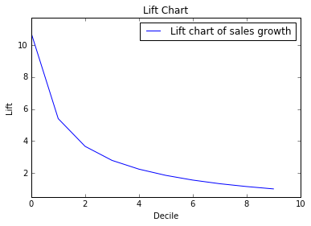

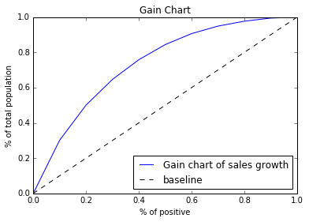

```python
%matplotlib inline
def assessment3(Result_matrix):
    plt.plot(Result_matrix.index.get_values(),Result_matrix['Lift_perc'].values, label='Lift chart of sales {0}'.format('growth'))
    plt.xlim([0.0, len(Result_matrix['Lift_perc']-1)])
    plt.ylim([0.5, min(max(Result_matrix['Lift_perc'])+1,20)])
    plt.xlabel('Decile')
    plt.ylabel('Lift')
    plt.title('Lift Chart')
    plt.legend(loc="best")

def assessment4(Result_matrix):

    #s = pd.Series([0],dtype="category")
    plt.plot(np.concatenate(([0],np.asarray(Result_matrix['Cul_tot_perc']))),np.concatenate(([0],np.asarray(Result_matrix['Cul_pos_perc']))), label='Gain chart of sales {0}'.format('growth'))
    plt.xlim([0.0, 1])
    plt.ylim([0.0, 1])
    plt.plot([0, 1], [0, 1], 'k--',label = 'baseline')
    plt.xlabel('% of positive')
    plt.ylabel('% of total population')
    plt.title('Gain Chart')
    plt.legend(loc="best")
    plt.show()

plt.figure()
assessment3(Result_matrix)
plt.show()
plt.figure()
assessment4(Result_matrix)
plt.show()
```

### Plot ROC curve

It is shown that ROC of train and test dataset are very close, which means our model does NOT overfit.

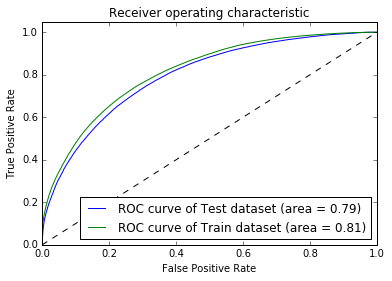

```python
%matplotlib inline


plt.figure()
fpr, tpr, _ = roc_curve(y_test['increase_sales'],proba[:,1],sample_weight = X_test.weight_sales.values)
roc_auc = auc(fpr, tpr,reorder = True)

plt.plot(fpr, tpr, label='ROC curve of Test dataset (area = {0:0.2f})'
                                       ''.format(roc_auc))
fpr, tpr, _ = roc_curve(y_train['increase_sales'],forest.predict_proba(X_train)[:,1],sample_weight = X_train.weight_sales.values)
roc_auc = auc(fpr, tpr,reorder = True)
plt.plot(fpr, tpr, label='ROC curve of Train dataset (area = {0:0.2f})'
                                       ''.format(roc_auc))


plt.plot([0, 1], [0, 1], 'k--')
plt.xlim([0.0, 1.0])
plt.ylim([0.0, 1.05])
plt.xlabel('False Positive Rate')
plt.ylabel('True Positive Rate')
plt.title('Receiver operating characteristic')
plt.legend(loc="lower right")
plt.show()
```

### Create and plot precision, recall ,and threshold

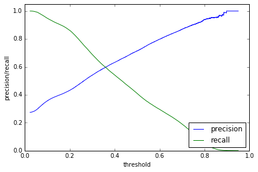

```python
def assessment1(y_test,proba):


        precision = dict()
        recall = dict()
        thresholds =dict()

        precision, recall, thresholds = precision_recall_curve(y_test,proba[:,1])

        plt.figure()
        plt.plot(thresholds,precision[:-1],
                     lw=1,

                     label = 'precision'
                     )


        plt.plot(thresholds,recall[:-1],
                 lw=1,
                 #linestyle='--',
                 label = 'recall'
                     )

        plt.tight_layout()

        plt.xlim([0.0, 1.0])
        plt.ylim([0.0, 1.05])
        plt.xlabel('threshold')
        plt.ylabel('precision/recall')
        plt.legend(loc="lower right")
        plt.show()
        return precision,recall,thresholds
precision,recall,thresholds=assessment1(y_test['increase_sales'],proba)
```

### Find best thresholds value based on F1 score, and generate confusion matrix

```python
max_F1_value = 0
for i,j,k in zip(precision,recall,thresholds[:-1]):
        F1 = 2 * (i * j) / (i + j)
        if F1 > max_F1_value:
            thr_set = k
            max_F1_value = F1

print 'Best thresholds which has max F1 value:'
print max_F1_value
print 'Those thresholds are:'
print thr_set


y_pred2 = pd.Series([j > thr_set for j in proba[:, 1]]).map({True:1,False:0}).values
print('confusion matrix: ')
print(confusion_matrix(y_test['increase_sales'],y_pred2))
```

```
Best thresholds which has max F1 value:
0.606363636364
Those thresholds are:
0.294137410276
confusion matrix:
[[121224  33639]
 [ 16590  38685]]
```

### Variable importance

Variable importance in random forest is impurity based ranking. Here I normalize them and print top 100 variables

```python
def rf_importance(forest):
    feat_labels = X_train.columns
    importances = forest.feature_importances_
    indices = np.argsort(importances)[::-1]

    importance_list = []
    for f in range(X_train.shape[1]):
        if f < 100:
            print("%2d) %-*s %f" % (f + 1, 30,
                               feat_labels[indices[f]],
                               importances[indices[f]]))
        importance_list.append((f,feat_labels[indices[f]],importances[indices[f]]))
    return importance_list
importance_list = rf_importance(forest)
```

```
 1) weight_sales                   0.096865
 2) SIC2D_P2_3                     0.078795
 3) ann_sls_us_dolr_amt_p          0.066421
 4) log_sale                       0.064905
 5) AGE_birth_P                    0.062485
 6) AGE_bus_P                      0.061220
 7) count_chg_phon                 0.035258
 8) count_change_dat               0.033772
 9) icm_ind                        0.027938
10) lgl_stat_code_p                0.024590
11) sig_upd_chg_tot_emp            0.024492
12) tot_emp_cnt_p                  0.024285
13) count_chg_tot_emp              0.023971
14) sig_upd_chg_sls_us_dolr        0.022057
15) count_chg_sls_us_dolr          0.018888
16) number_updtes_2014             0.018751
17) emp_at_locn_cnt_p              0.018270
18) ma_ttl_o_cc9p_3m_q3            0.014740
19) count_icm_update               0.014329
20) ma_ttl_o_cc9p_2h6m             0.012354
21) SIC2D_P2_9                     0.011912
22) ma_ttl_o_cc7p_3m_q3            0.011462
23) SIC2D_P2_7                     0.010539
24) count_chg_emp_hre              0.010361
25) sig_upd_chg_emp_hre            0.008887
26) ma_ttl_o_cc7p_2h6m             0.008034
27) count_change_ope               0.007050
28) SIC2D_P2_4                     0.005477
29) max_ttl_9p_fl_6m               0.004727
30) ma_ttl_o_cc7p_3m_q2            0.004433
31) ma_signal_ind_b_cc9p_1h6m      0.004358
32) SIC2D_P2_6                     0.004028
33) mktb_ind_p                     0.003830
34) ma_ttl_o_cc9p_3m_q2            0.003565
35) max_ttl_9p_q1toq4              0.003550
36) ma_signal_b_cc9p_1h6m          0.003387
37) ma_ttl_cc9p_q3                 0.003361
38) sig_updt_chg_fam_mbr_glbl      0.003236
39) num_all_branch_p               0.003051
40) ma_ttl_cc9p_2h6m               0.003049
```

[output cut: 45 more lines]

```
86) min_ttl_9p_fl_6m               0.001092
87) ma_signal_ind_b_3m_cc9p_q2     0.001087
88) min_ttl_7p_q1toq4              0.001054
89) ma_ttl_cc9p_q3q4               0.001033
90) ma_cnt_months_q2               0.001031
91) ma_ttl_o_cc9p_1h6m             0.001008
92) stand_alone_p                  0.001005
93) ma_ttl_cc7p_126m               0.000980
94) SIC2D_P2_5                     0.000948
95) ma_signal_b_3m_cc7p_q1         0.000919
96) ma_ttl_o_cc7p_3m_q4            0.000916
97) mean_cnt_months_q1toq4         0.000908
98) ma_ttl_cc7p_q1                 0.000907
99) min_cnt_months_q1toq4          0.000900
100) SIC2D_P2_1                     0.000879
```

### Pickle: store any object to external space for future use

```python
import pickle
output = open('/data2/GMC/sales_model/pickle/test.pkl', 'wb')
pickle.dump(importance_list, output)
output.close()
```

#### Load the pickle into memory for instant use

```python
pkl_file = open('/data2/GMC/sales_model/pickle/test.pkl', 'rb')

inp = pickle.load(pkl_file)

pkl_file.close()

#inp
```

### Joblib : specifically store sklearn model to external space for future use

#### This will be our score code

```python
# store sklearn model
from sklearn.externals import joblib
A = joblib.dump(forest, '/data2/GMC/sales_model/pickle/forest_demo.pkl')
```

```python
B = joblib.load('/data2/GMC/sales_model/pickle/forest_demo.pkl')
```

### Out-of-time validation

By default Python load the whole file into memory. When dealing with large files, it is recommended to split file into chunks. Score each chunk sequentially, and only keep the output target variable.

```python
import pandas as pd
reader = pd.read_csv('/data2/GMC/sales_model/SALES_DEVELOPMENT_cris.csv', iterator=True)

loop = True
chunkSize = 500000
y_set_oot = pd.Series([])
proba_pred_set_oot = pd.DataFrame([])
X_weight_set_oot = pd.Series([])
i= 1
while loop:
    start_time = time.time()
    try:
        chunk = reader.get_chunk(chunkSize)
        chunk = chunk.set_index(chunk.duns)
        chunk2 = preprocess(chunk)
        y=chunk2['increase_sales']
        X=chunk2.drop(['increase_sales','nochange_sales','decrease_sales','sales_pct_ALL','ann_sls_ind_c','ann_sls_ind_p',\
                 'ann_sls_us_dolr_amt_c','duns','hq_par_ctry_cd_c','dlst_ind_p','dlst_ind_c'],1)
        misscolumn = (set(X_train.columns.values)-set(X.columns.values))
        for a in misscolumn:
            X[a]=0
        proba_pred = forest.predict_proba(X)
        proba_pred = pd.DataFrame(proba_pred).set_index(chunk.duns)
        proba_pred_set_oot=pd.concat([proba_pred_set_oot,proba_pred], axis=0)

        X_weight_set_oot = pd.concat([X_weight_set_oot,X['weight_sales']])
        y_set_oot = pd.concat([y_set_oot,y])
        print("---Chunk %s :  %s seconds ---" % (i,time.time() - start_time))
        i= i+1

    except StopIteration:
        loop = False
        print "Iteration is stopped."
```

```
---Chunk 1 :  46.687361002 seconds ---
---Chunk 2 :  45.708561182 seconds ---
---Chunk 3 :  46.4654848576 seconds ---
---Chunk 4 :  45.8955719471 seconds ---
---Chunk 5 :  46.5466461182 seconds ---
---Chunk 6 :  43.8990299702 seconds ---
---Chunk 7 :  43.8397400379 seconds ---
---Chunk 8 :  44.0571889877 seconds ---
---Chunk 9 :  44.6484498978 seconds ---
---Chunk 10 :  44.6002459526 seconds ---
---Chunk 11 :  44.3690330982 seconds ---
---Chunk 12 :  44.7457110882 seconds ---
---Chunk 13 :  44.1256408691 seconds ---
---Chunk 14 :  43.7144539356 seconds ---
---Chunk 15 :  45.6039688587 seconds ---
---Chunk 16 :  45.7981500626 seconds ---
---Chunk 17 :  44.9036800861 seconds ---
---Chunk 18 :  10.2807309628 seconds ---
Iteration is stopped.
```

### Grid search : Use Cross-Validation methods to find optimal hyperparmaters

This is a standard step for machine learning to avoid overfitting. You can also define your own scoring function.

```python
from sklearn.grid_search import GridSearchCV
min_samples_leaf_range = np.linspace(12,30,10).astype(int)
max_depth_range= np.linspace(30,50,5).astype(int)
max_features_range = np.linspace(10,50,5).astype(int)

forest1 = RandomForestClassifier()
param_grid1 = {
        'min_samples_leaf':min_samples_leaf_range,
        'max_depth':max_depth_range,
        'max_features':max_features_range
        }
gs1 = GridSearchCV(estimator = forest1,
                      param_grid=param_grid1,
                          scoring = 'roc_auc',
                       cv = 3,
                          n_jobs=32)
gs1 = gs1.fit(X_train,y_train['increase_sales'])
```

```python
gs1.best_estimator_
```

```
RandomForestClassifier(bootstrap=True, class_weight=None, criterion='gini',
            max_depth=45, max_features=50, max_leaf_nodes=None,
            min_samples_leaf=14, min_samples_split=2,
            min_weight_fraction_leaf=0.0, n_estimators=10, n_jobs=1,
            oob_score=False, random_state=None, verbose=0,
            warm_start=False)
```

```python
gs1.best_params_
```

```
{'max_depth': 45, 'max_features': 50, 'min_samples_leaf': 14}
```

```python
gs1.best_score_
```

```
0.85223562845300371
```